# Пространственные паттерны в отловах птиц 2

## Подготовка данных

В качестве матрицы зависимых переменных будем использовать количество пойманных птиц деленное на количество дней отловов. То есть количество птиц данного вида, приходящееся на один день отлова.

| Site | Years | n |
| --- | --- | --- |
| Dzhanybek, KZ_1 | 2003, 2004 | 63 |
| Dzhanybek, KZ_2 | 2021 | 9 |
| Camel Rock, RU | 2023 | 10 |
| Ak Kertysh, KZ | 2024 | 11 |
| Samur Delta, RU_1 | 1988 | 32 |
| Samur Delta, RU_2 | 2018, 2019, 2022-2024 | 12 |
| Lower Kuma River, RU | 2019, 2021-2023 | 8 |
| Novaya Derevnya; RU | 2013 | 15 |
| Shangina, RU | 2014 | 22 |
| Kukarskoe Lake, RU | 2016 | 26 |
| Barsakelmes, KZ | 1986 | 21 |
| Repetek, TM | 1981 | 93 |
| Ufra, TM | 1982 | 73 |
| San Tash, KG | 1981, 1982 | 33 |
| Sary Tash, KG | 1981 | 38 |
| Ala Archa, KG | 1983, 1984 | 106 |
| Madian, TJ | 1984 | 36 |
| Kyzylkum res. Station, UZ | 1972 | 24 |
| Chokpak, KZ | 2001-2024 | 1375 |
| Lower Ural River, KZ | 1973-1975 | 219 |
| Uralsk, KZ | 1976-1979 | 263 |
| Sorbulak Lake, KZ | 1977-1984, 2001-2004, 2006-2009 | 918 |
| Lower Turgai River, KZ | 1975-1977, 1983, 1985 | 168 |
| Sasykkol Lake, KZ | 1981, 1989 | 101 |
| Alakol Lake, KZ | 1987, 1990-1993 | 186 |

Так выглядит карта расположения точек отлова птиц.Размер точки пропорционален количеству дней отлова.

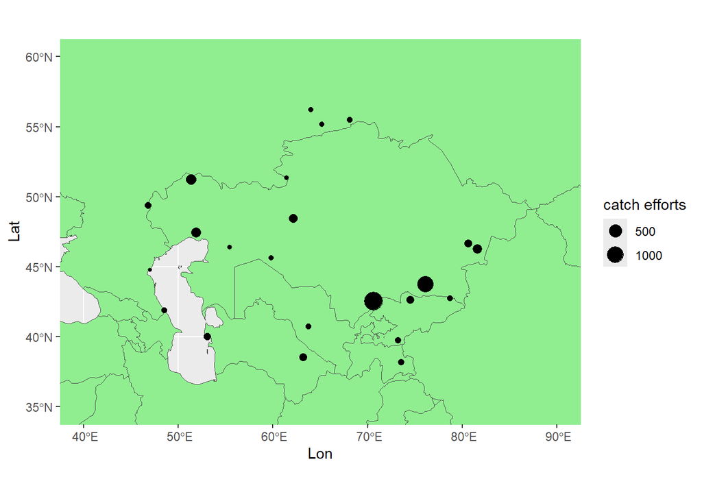

## Модель географической приуроченности видов

Главными предикторами, в соответствии с задачей, будем рассматривать географические координаты (Lon, Lat). Однако, как справедливо было отмечено, соотношение численностей видов птиц может контролироваться еще и тем, в какой стации были установлены сети. Для обхода этой проблемы предлагается в качестве ковариат использовать также общее обилие трех групп птиц, различающихся по своей “экологии”.Группы далее обозначаются так

- **Phyl** - “пеночки”
- **Acro** - “камышевки”
- **Fice** - “мухоловки”

Для контроля вывожу таблицу с оценкой обилия птиц каждой группы на сайтах. Это суммарное количество птиц каждой группы.

| Site | Lat | Lon | Acro | Fice | Phyl |
| --- | --- | --- | --- | --- | --- |
| Ak Kertysh, KZ | 46.40000 | 55.41 | 39 | 7 | 42 |
| Ala Archa, KG | 42.65000 | 74.50 | 11 | 4 | 135 |
| Alakol Lake, KZ | 46.27000 | 81.60 | 5503 | 24 | 452 |
| Barsakelmes, KZ | 45.63000 | 59.79 | 50 | 4 | 7 |
| Camel Rock, RU | 51.37000 | 61.39 | 39 | 49 | 247 |
| Chokpak, KZ | 42.52000 | 70.63 | 1199 | 1317 | 5746 |
| Dzhanybek, KZ_1 | 49.40000 | 46.80 | 76 | 874 | 637 |
| Dzhanybek, KZ_2 | 49.40000 | 46.80 | 29 | 12 | 67 |
| Kukarskoe Lake, RU | 55.50000 | 68.08 | 214 | 32 | 768 |
| Kyzylkum res. Station, UZ | 40.74000 | 63.75 | 100 | 1 | 950 |
| Lower Kuma River, RU | 44.76000 | 46.99 | 272 | 5 | 27 |
| Lower Turgai River, KZ | 48.47000 | 62.15 | 1315 | 1 | 13 |
| Lower Ural River, KZ | 47.45000 | 51.87 | 52 | 234 | 592 |
| Madian, TJ | 38.18000 | 73.56 | 2 | 3 | 12 |
| Novaya Derevnya; RU | 55.18000 | 65.19 | 11 | 0 | 334 |
| Repetek, TM | 38.56000 | 63.17 | 36 | 28 | 42 |
| Samur Delta, RU_1 | 41.89000 | 48.51 | 34 | 4 | 2 |
| Samur Delta, RU_2 | 41.89000 | 48.51 | 30 | 6 | 54 |
| San Tash, KG | 42.75000 | 78.70 | 7 | 0 | 164 |
| Sary Tash, KG | 39.74000 | 73.22 | 18 | 3 | 289 |
| Sasykkol Lake, KZ | 46.68333 | 80.60 | 727 | 9 | 241 |
| Shangina, RU | 56.22000 | 64.00 | 6 | 4 | 389 |
| Sorbulak Lake, KZ | 43.77000 | 76.08 | 2710 | 95 | 2626 |
| Ufra, TM | 40.00000 | 53.10 | 26 | 11 | 21 |
| Uralsk, KZ | 51.23000 | 51.35 | 44 | 52 | 705 |

А это в пересчете на один день отлова (именно эту величину я далее буду использовать в качестве ковариаты).

| Site | Lat | Lon | Acro_per_Day | Fice_per_Day | Phyl_per_Day |
| --- | --- | --- | --- | --- | --- |
| Ak Kertysh, KZ | 46.40000 | 55.41 | 3.5 | 0.6 | 3.8 |
| Ala Archa, KG | 42.65000 | 74.50 | 0.1 | 0.0 | 1.3 |
| Alakol Lake, KZ | 46.27000 | 81.60 | 29.6 | 0.1 | 2.4 |
| Barsakelmes, KZ | 45.63000 | 59.79 | 2.4 | 0.2 | 0.3 |
| Camel Rock, RU | 51.37000 | 61.39 | 3.9 | 4.9 | 24.7 |
| Chokpak, KZ | 42.52000 | 70.63 | 0.9 | 1.0 | 4.2 |
| Dzhanybek, KZ_1 | 49.40000 | 46.80 | 1.2 | 13.9 | 10.1 |
| Dzhanybek, KZ_2 | 49.40000 | 46.80 | 3.2 | 1.3 | 7.4 |
| Kukarskoe Lake, RU | 55.50000 | 68.08 | 8.2 | 1.2 | 29.5 |
| Kyzylkum res. Station, UZ | 40.74000 | 63.75 | 4.2 | 0.0 | 39.6 |
| Lower Kuma River, RU | 44.76000 | 46.99 | 34.0 | 0.6 | 3.4 |
| Lower Turgai River, KZ | 48.47000 | 62.15 | 7.8 | 0.0 | 0.1 |
| Lower Ural River, KZ | 47.45000 | 51.87 | 0.2 | 1.1 | 2.7 |
| Madian, TJ | 38.18000 | 73.56 | 0.1 | 0.1 | 0.3 |
| Novaya Derevnya; RU | 55.18000 | 65.19 | 0.7 | 0.0 | 22.3 |
| Repetek, TM | 38.56000 | 63.17 | 0.4 | 0.3 | 0.5 |
| Samur Delta, RU_1 | 41.89000 | 48.51 | 1.1 | 0.1 | 0.1 |
| Samur Delta, RU_2 | 41.89000 | 48.51 | 2.5 | 0.5 | 4.5 |
| San Tash, KG | 42.75000 | 78.70 | 0.2 | 0.0 | 5.0 |
| Sary Tash, KG | 39.74000 | 73.22 | 0.5 | 0.1 | 7.6 |
| Sasykkol Lake, KZ | 46.68333 | 80.60 | 7.2 | 0.1 | 2.4 |
| Shangina, RU | 56.22000 | 64.00 | 0.3 | 0.2 | 17.7 |
| Sorbulak Lake, KZ | 43.77000 | 76.08 | 3.0 | 0.1 | 2.9 |
| Ufra, TM | 40.00000 | 53.10 | 0.4 | 0.2 | 0.3 |
| Uralsk, KZ | 51.23000 | 51.35 | 0.2 | 0.2 | 2.7 |

Теперь про зависимую переменную. Моделировать, на мой взгляд, надо вероятность встречи *вида* среди отловленных птиц. Соответственно, это будет доля каждого вида в общей численности пойманных на данной станции птиц.

Полученные в анализе канонические оси в сумме описывают 62.4% общей инерции (of total Inertia). Сама модель была статистически значимой (здесь и далее для оценки величины p-value использована пермутационная процедура при 9999 пермутациях).

| term | df | ChiSquare | statistic | p.value |
| --- | --- | --- | --- | --- |
| Model | 5 | 1.826570 | 6.294065 | 1e-04 |
| Residual | 19 | 1.102779 | NA | NA |

При этом статистически значимыми были все пять канонических осей.

| term | df | ChiSquare | statistic | p.value |
| --- | --- | --- | --- | --- |
| CCA1 | 1 | 0.6334029 | 10.913021 | 0.0001 |
| CCA2 | 1 | 0.5123955 | 8.828161 | 0.0001 |
| CCA3 | 1 | 0.3487833 | 6.009255 | 0.0001 |
| CCA4 | 1 | 0.1735721 | 2.990508 | 0.0400 |
| CCA5 | 1 | 0.1584159 | 2.729378 | 0.0277 |
| Residual | 19 | 1.1027794 | NA | NA |

Влияние каждого из предикторов, включенных в модель, также была значима. Ниже приводится ANOVA для Marginal effects of terms, то есть это аналог для SS Type2 (оценка значимости предиктора при сравнении полной модели с моделью без его участия).

| term | df | ChiSquare | statistic | p.value |
| --- | --- | --- | --- | --- |
| Acro_per_Day | 1 | 0.4108963 | 7.079411 | 0.0001 |
| Fice_per_Day | 1 | 0.2608536 | 4.494297 | 0.0035 |
| Phyl_per_Day | 1 | 0.2072744 | 3.571170 | 0.0152 |
| Lat | 1 | 0.2333481 | 4.020399 | 0.0011 |
| Lon | 1 | 0.3400174 | 5.858225 | 0.0001 |
| Residual | 19 | 1.1027794 | NA | NA |

Однако Для поставленных целей лучше использовать другой тип ANOVA (Terms added sequentially (first to last)). См. таблицу ниже. Это налог SS Type1 для обычной ANOVA. Мы смотрим на то, как влияют предикторы интереса (Lat и Lon) после того как учтено влияние “технических” ковариат (обилия трех групп видов). Здесь все опять супер! Географический паттерн есть даже после “удаления” влияния ковариат, связанных с чем-то, что отражают численности трех групп видов.

| term | df | ChiSquare | statistic | p.value |
| --- | --- | --- | --- | --- |
| Acro_per_Day | 1 | 0.5432161 | 9.359174 | 1e-04 |
| Fice_per_Day | 1 | 0.3709706 | 6.391524 | 1e-04 |
| Phyl_per_Day | 1 | 0.3373143 | 5.811654 | 1e-04 |
| Lat | 1 | 0.2350513 | 4.049745 | 1e-03 |
| Lon | 1 | 0.3400174 | 5.858225 | 1e-04 |
| Residual | 19 | 1.1027794 | NA | NA |

Вот визуализация модели.

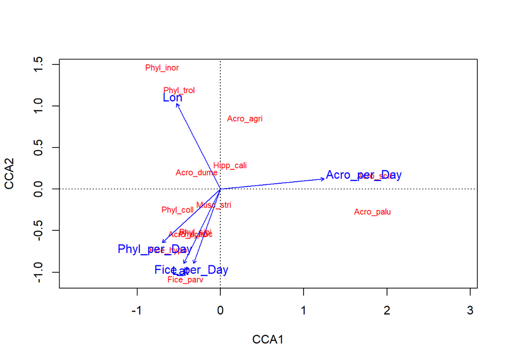

**Fig. ++**. Ординация видов в канонических осях, заданных географическими координатами расположения станций кольцевания

Для трактовки канонических осей привожу таблицу с нагрузками для предикторов.

|  | CCA1 | CCA2 | CCA3 | CCA4 | CCA5 |
| --- | --- | --- | --- | --- | --- |
| Acro_per_Day | 0.8811757 | 0.0873646 | 0.2395121 | -0.3949620 | -0.0503564 |
| Fice_per_Day | -0.2285771 | -0.6328132 | -0.6386443 | -0.3349947 | -0.1649607 |
| Phyl_per_Day | -0.4943686 | -0.4555652 | 0.5281768 | -0.2442882 | 0.4576162 |
| Lat | -0.3131938 | -0.6331795 | 0.5423396 | -0.0913250 | -0.4455568 |
| Lon | -0.3746633 | 0.7303244 | 0.3891146 | -0.4054211 | -0.1023584 |

Первые три корреспондентные оси описывают 51% общей инерции, то есть большуую часть изменчивости. Поэтому сосредоточимся на них.

Видно, что 1 и 3 канонические оси - это что-то про относительное обилие трех когорт птиц. То есть это история про биотопы, в которых отлавливали птиц.

|  | CCA1 | CCA2 | CCA3 | CCA4 | CCA5 |
| --- | --- | --- | --- | --- | --- |
| Phyl_trol | -0.4968486 | 1.1876389 | -0.1146425 | -0.1665263 | -0.0843224 |
| Phyl_coll | -0.5127547 | -0.2502793 | 0.5556672 | -0.1006091 | 0.9940544 |
| Phyl_troc | -0.2937607 | -0.5404104 | 0.3742235 | 0.6566121 | -0.4302451 |
| Phyl_inor | -0.7008012 | 1.4613255 | -0.4728584 | 0.1059332 | 0.3260278 |
| Phyl_sibi | -0.3012244 | -0.5174969 | -0.7803455 | -0.0126768 | 0.3710137 |
| Acro_scir | 1.8523754 | 0.1590134 | 0.1467443 | -0.4843853 | -0.0224574 |
| Acro_dume | -0.2800358 | 0.2009489 | 0.2758047 | 0.0463524 | 0.1499954 |
| Acro_agri | 0.2948377 | 0.8485132 | 0.2760391 | -0.5954067 | -0.5619966 |
| Acro_palu | 1.8313662 | -0.2715692 | -0.1306739 | 0.3688577 | 0.3901874 |
| Acro_scho | -0.3902125 | -0.5460070 | 0.9397022 | -0.0874275 | -0.1513352 |
| Hipp_cali | 0.1195708 | 0.2857811 | 0.0021575 | 0.6716903 | -0.3929512 |
| Fice_parv | -0.4201802 | -1.0888969 | -1.2703261 | -0.5928301 | -0.2646973 |
| Fice_hypo | -0.6244933 | -0.7373173 | 0.7630040 | -0.3485844 | -0.1242734 |
| Musc_stri | -0.0778385 | -0.1912440 | -0.5644962 | 0.5390006 | -0.1990001 |

Таким образом, первую и третью каноническую ось оставляем для дальнейшего размышления. Они про ту изменчивость, которая за рамками данной работы.

Далее сосредоточимся на второй канонической оси (CCA2). Эта ось описывает 17.5% общей инерции. И она явно про географию, так как долгота (Lon) и широта (Lat) с ней коррелируют. Учитывая разнонаправленною связь широты (отрицательно связана с CCA2) и долготы (положительно связана с CCA2) эту ось я бы трактовал как некий градиент с Северо-Запада на Юго-Восток.

Те виды, которые имеют положительные нагрузки по CCA2 более обильны в отловах в юго-восточных локациях, те виды, которые имеют отрицательную нагрузку - в северо-западных локациях.

Чтобы не путать с “экологическими” группами видов буду использовать термин “географическая группа”

Вот состав этих географических групп. Географическая группа 1: Phyl_trol, Phyl_inor, Acro_scir, Acro_dume, Acro_agri, Hipp_cali.

Географическая группа 2: Phyl_coll, Phyl_troc, Phyl_sibi, Acro_palu, Acro_scho, Fice_parv, Fice_hypo, Musc_stri.

## Карты отловов географическоой группы 1 (положительные значения CCA2)

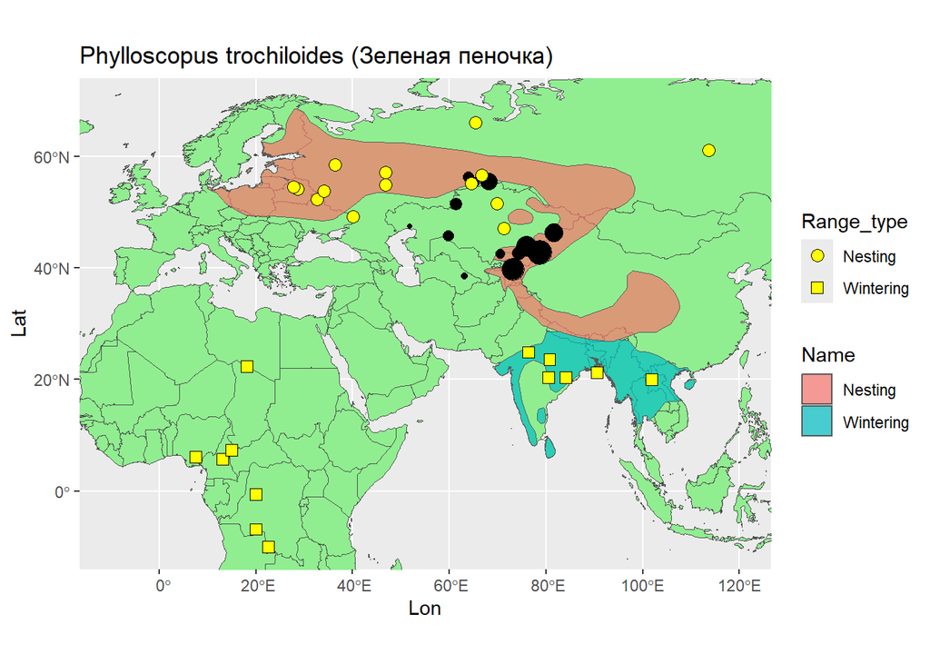

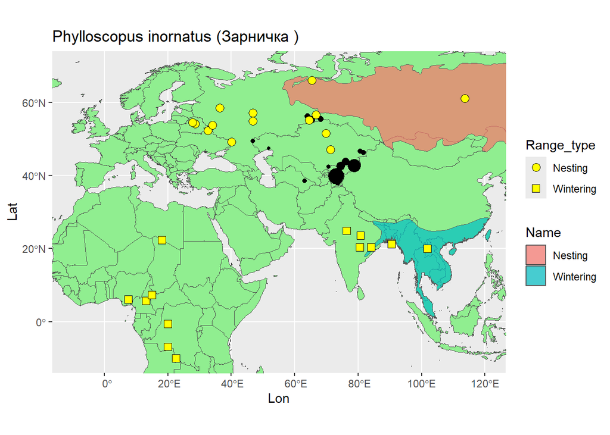

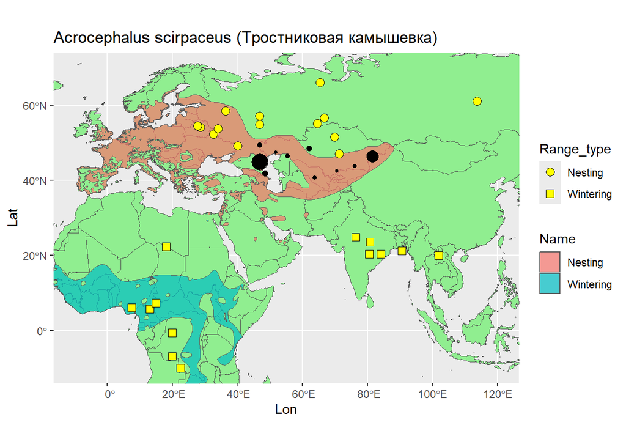

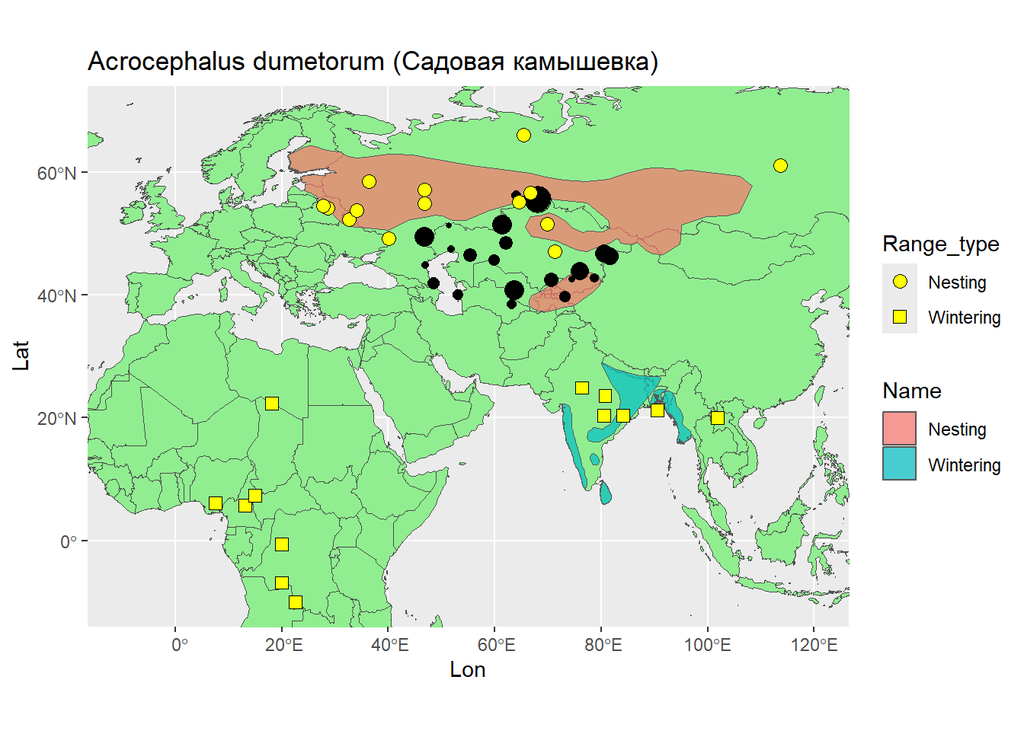

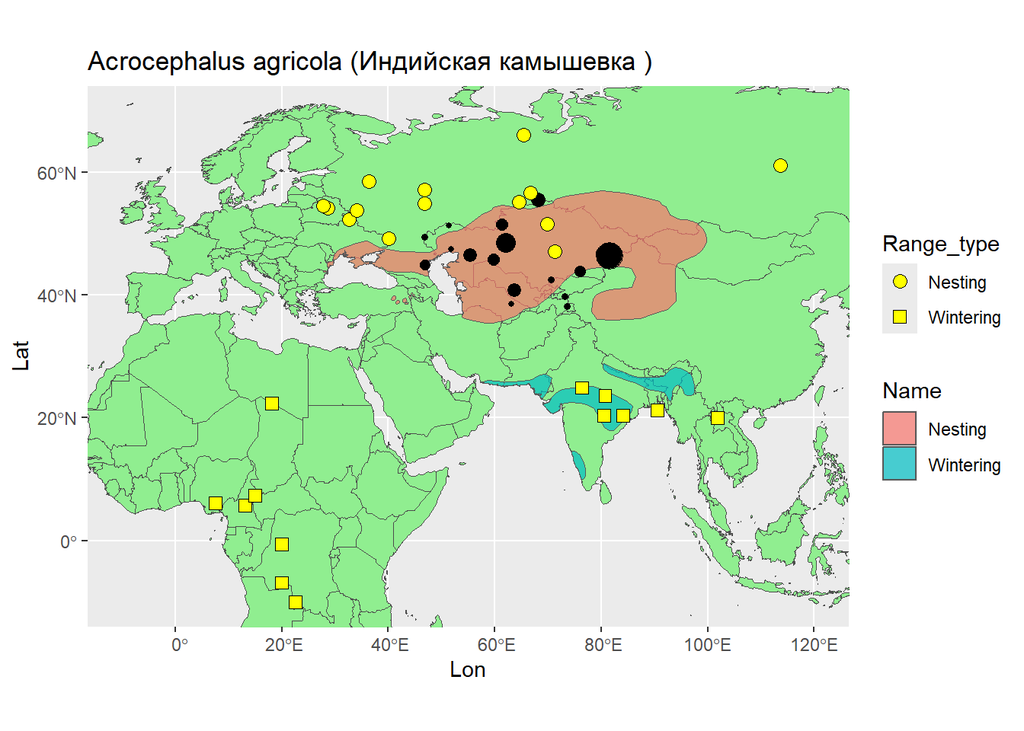

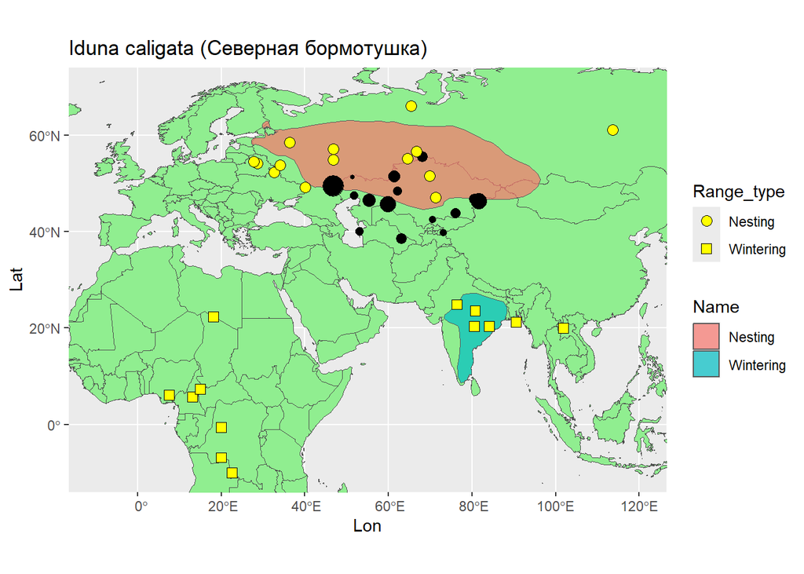

## Карты отловов географической группы 2 (отрицательные значения CCA2)

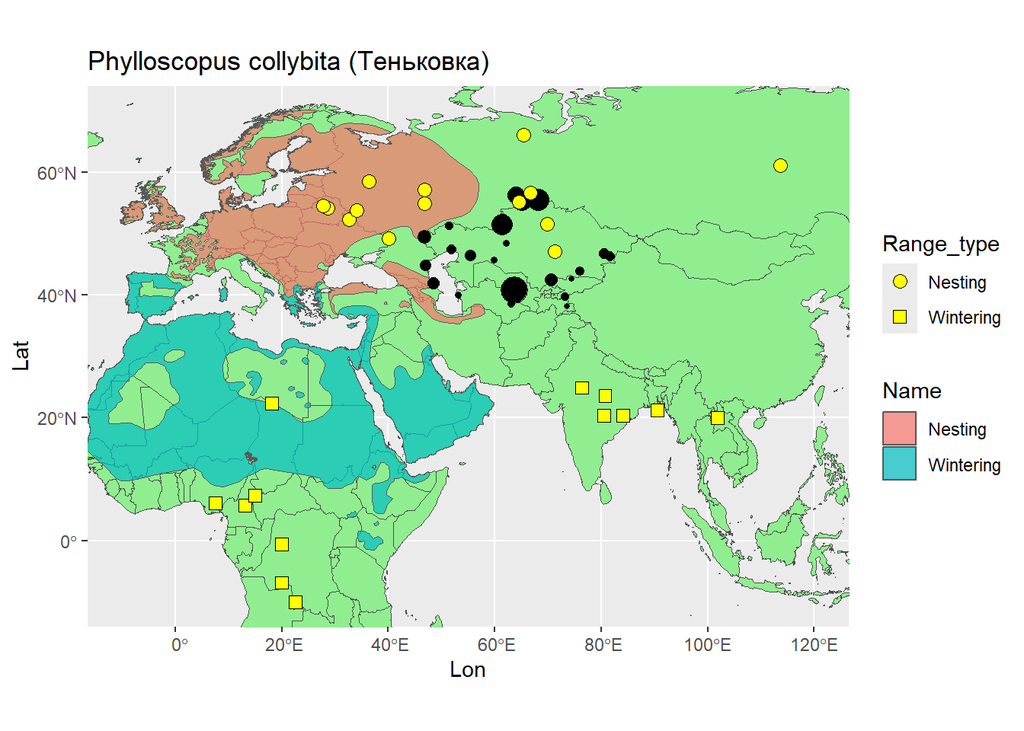

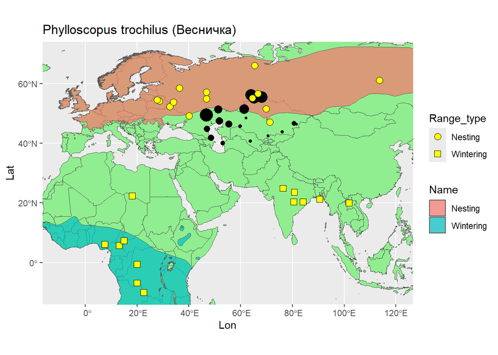

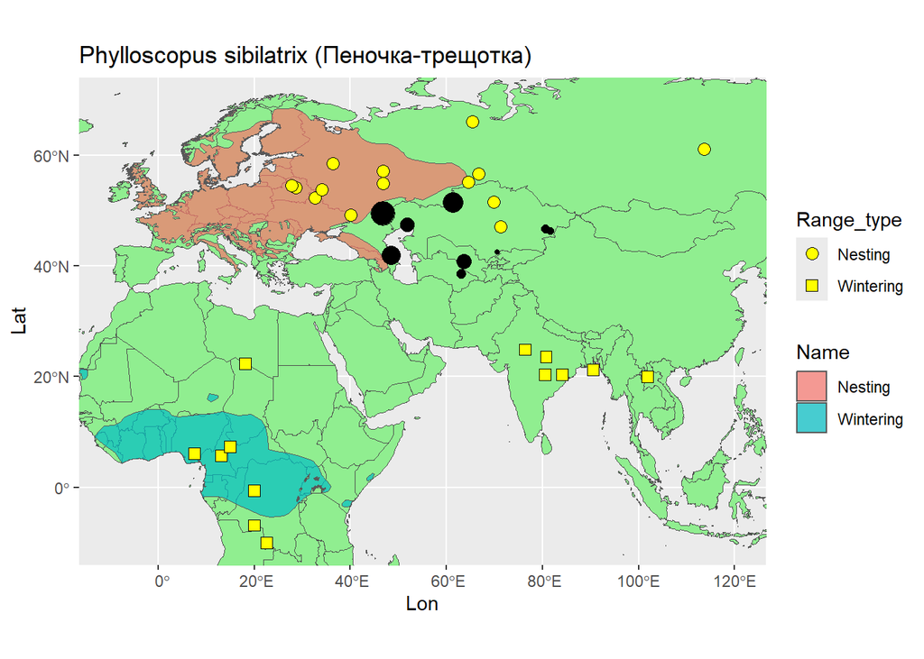

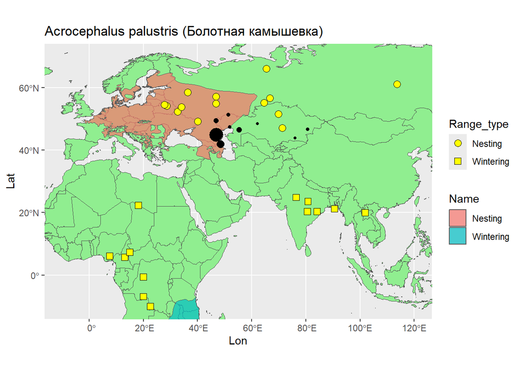

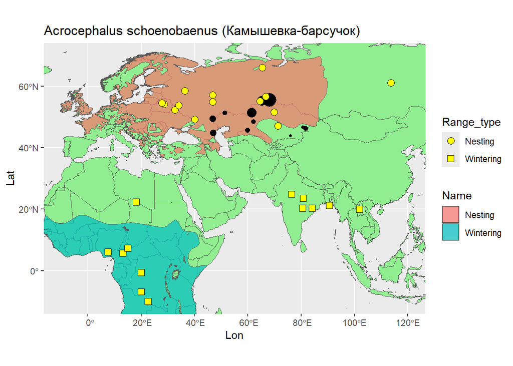

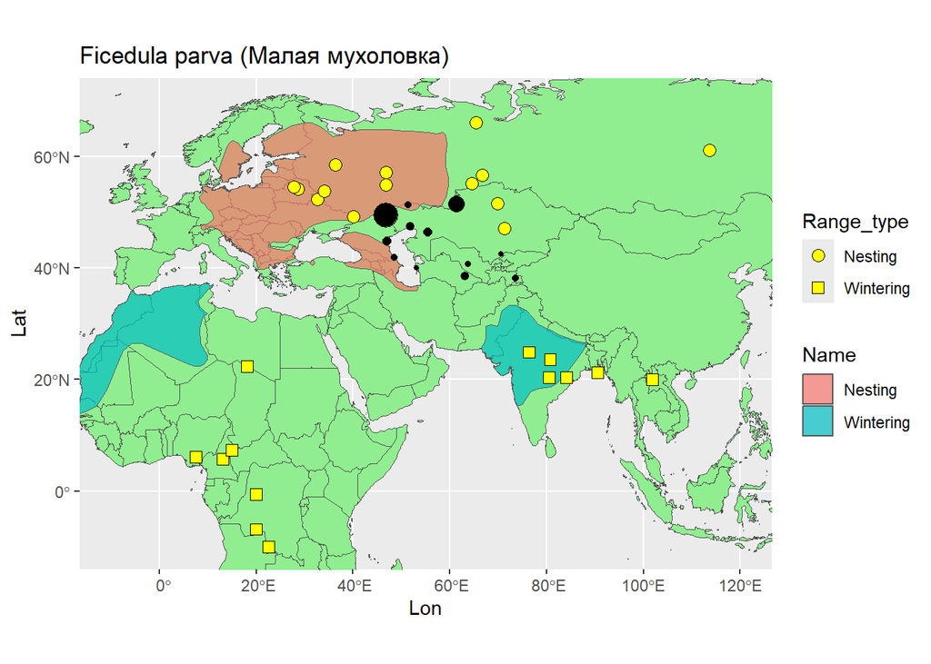

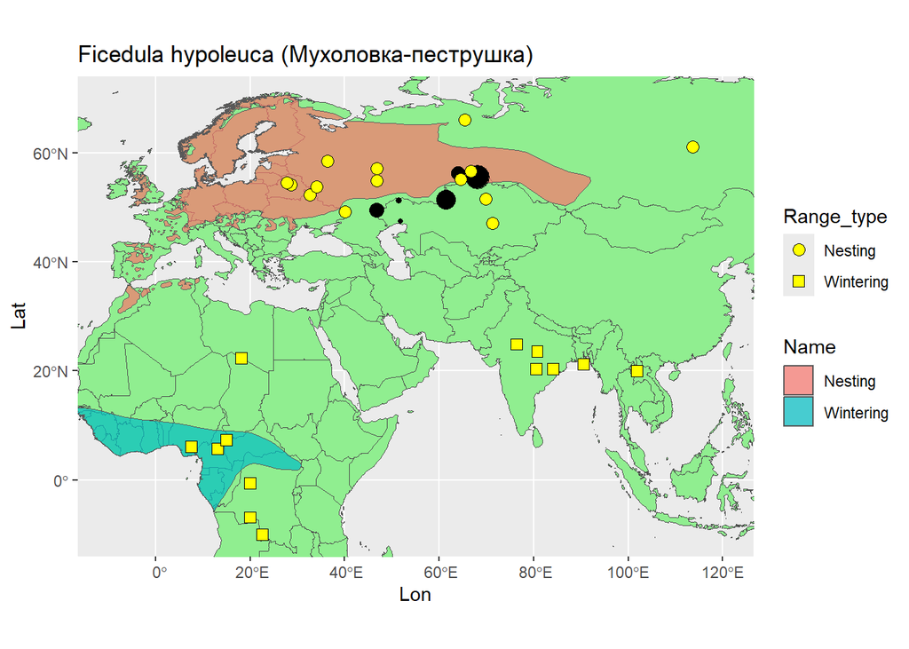

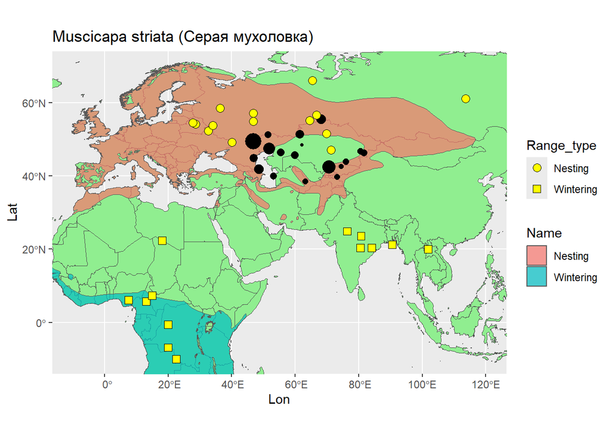

## Итого

Из 6 видов первой географической группы (Положительно связаны с CCA2) 5 летит в Индию и Ю-В Азию.

Из 8 видов второй географической группы (Отрицательно связаны с CCA2) 7 летит в Африку.

По-моему, неплохая дифференцирующая сила для модели.

Ну и для обобщения, вот карта с распределением значений нагрузок по CCA2. Здесь размер точки пропорционален значению CCA2, а заливка обозначает CCA2 больше нуля (зеленые, по идее на сайте доминируют птицы из географической группы 1) или CCA2 меньше нуля (розовые, доминируют виды из географической группы 2).

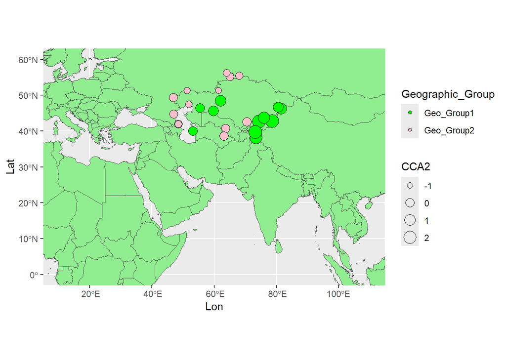

```
## Wintering_Lat Wintering_Lon
##      1.782383      1.782383
```

```
##
## Call:
## lm(formula = CCA2 ~ Wintering_Lat + Wintering_Lon, data = ordination_df)
##
## Residuals:
##      Min       1Q   Median       3Q      Max
## -1.47571 -0.17788 -0.07444  0.35400  0.66650
##
## Coefficients:
##                Estimate Std. Error t value Pr(>|t|)
## (Intercept)   -0.688779   0.274017  -2.514   0.0288 *
## Wintering_Lat -0.003782   0.015399  -0.246   0.8105
## Wintering_Lon  0.015310   0.006186   2.475   0.0309 *
## ---
## Signif. codes:  0 '***' 0.001 '**' 0.01 '*' 0.05 '.' 0.1 ' ' 1
##
## Residual standard error: 0.5903 on 11 degrees of freedom
## Multiple R-squared:  0.4657, Adjusted R-squared:  0.3686
## F-statistic: 4.794 on 2 and 11 DF,  p-value: 0.03182
```

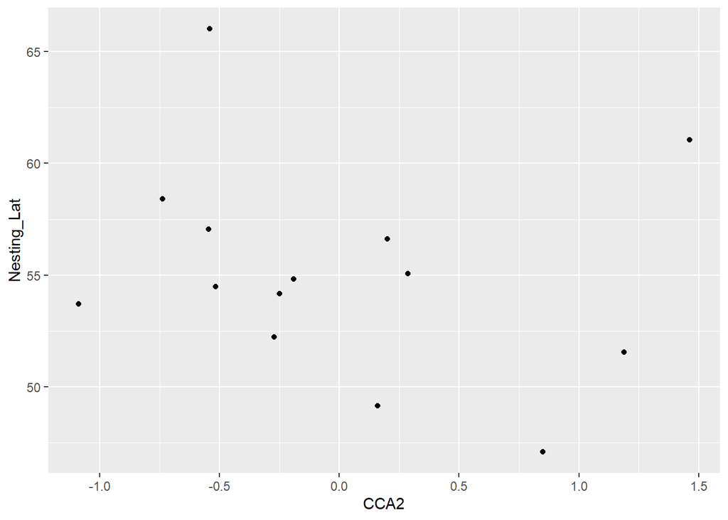

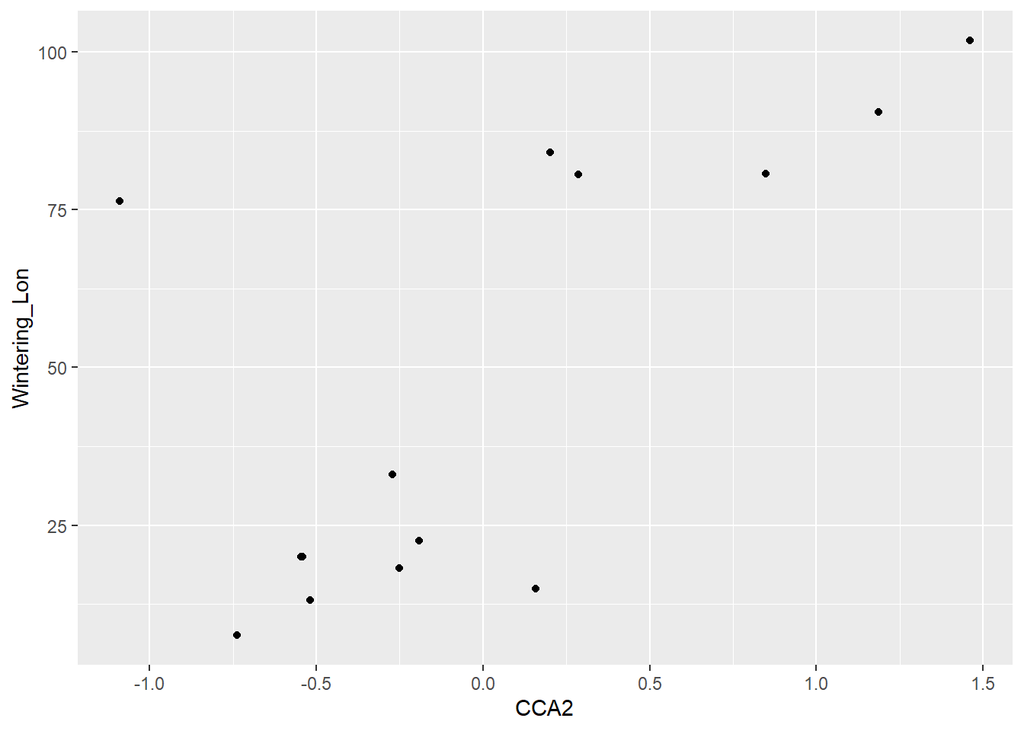

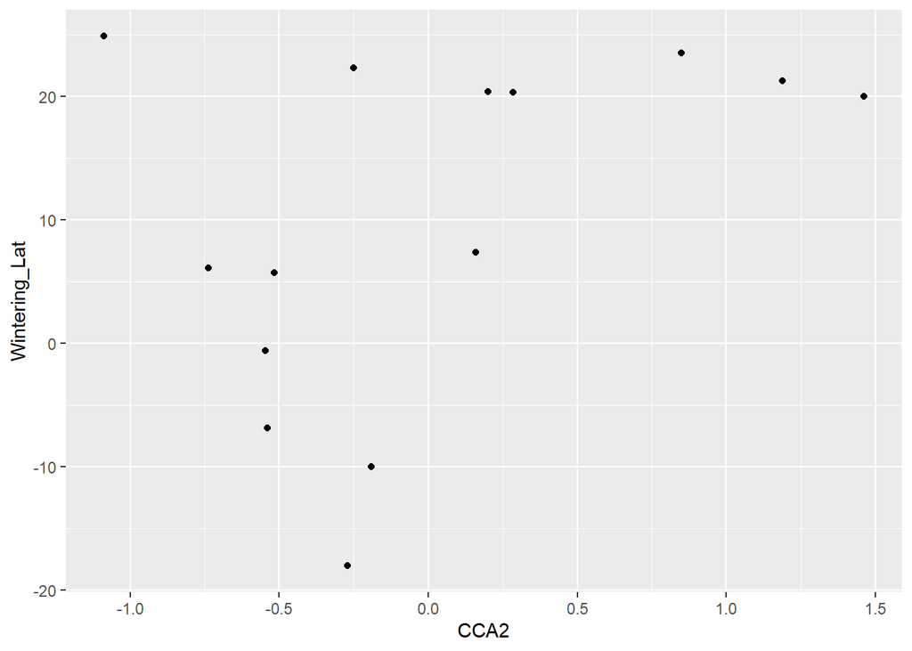

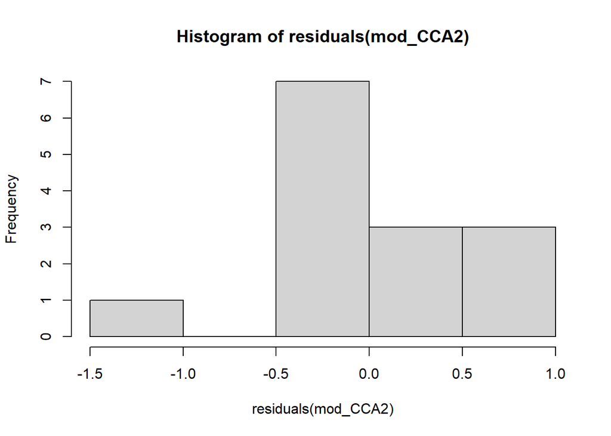

```
##         Sci_Name Nesting_Lat Nesting_Lon Wintering_Lat Wintering_Lon       CCA1
## 7 Ficedula parva    53.71528    34.01916      24.86909      76.40039 -0.4201802
##        CCA2
## 7 -1.088897
```